# 3. Semiparametric Regression

Edoardo Cortolezzis

2025-01-15

# Excercise 3: Semiparametric regression

**Consider the data in https://www.kaggle.com/datasets/sameersmahajan/seattle-house-sales-prices. Price is your response variable y.**

```r
d=read.csv("datasets/house_sales.csv",header=TRUE)
```

Before fitting the model, let’s take a look at the dataset. It has 21613 observations across 21 variables:

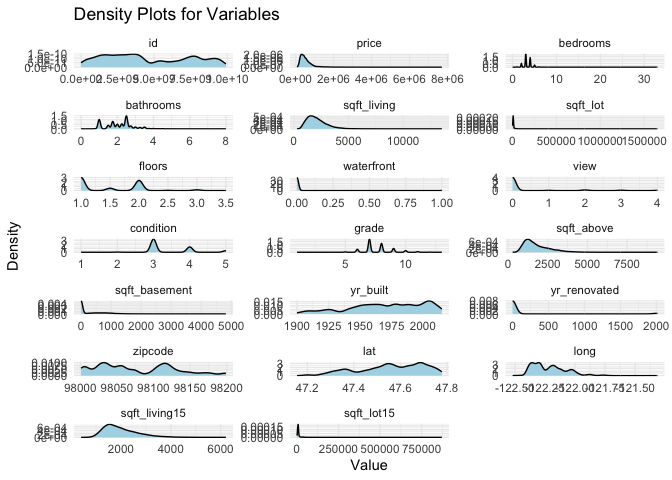

The plots reveal several variables exhibiting skewness, including ‘price’ and ‘sqft_living.’ To address this, incorporating the log transformation of these variables into the model may improve its performance and interpretability.

## Fit a semiparametric regression model

Model formula:
$$y_i = f(x_i) + \epsilon_i, \quad \epsilon_i \sim i.i.d. \, ~N(0,
\sigma^2)$$
Where:

- **$y_i$** is the house price for observation $i$;
- **$x_i$** is sqft_living variable, so the square footage of the living area;
- **$f(x_i)$** is a smooth function estimated from the data;
- **$\epsilon_i$** are the error terms, assumed to be normally distributed with mean 0 and variance $\sigma^2$.

Before fitting the model, we can look at the data distributions of the predictor and the response and their correlation:

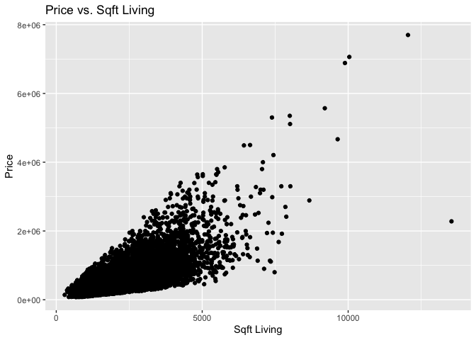

```
## [1] "The correlation between the variables is 0.702035052433682"
```

As we can see, the 2 variables are higly correlated. Therefore, the spline model might be a good fit for the data.

```r
model <- gam(price ~ s(sqft_living), data = d)
```

## Discuss the model fit, explain why the model is not adequate and propose how to improve it.

### Model Fit discussion:

- Summary:

```r
summary(model)
```

```
##
## Family: gaussian
## Link function: identity
##
## Formula:
## price ~ s(sqft_living)
##
## Parametric coefficients:
##             Estimate Std. Error t value Pr(>|t|)
## (Intercept)   540088       1675   322.4   <2e-16 ***
## ---
## Signif. codes:  0 '***' 0.001 '**' 0.01 '*' 0.05 '.' 0.1 ' ' 1
##
## Approximate significance of smooth terms:
##                  edf Ref.df    F p-value
## s(sqft_living) 8.986      9 2936  <2e-16 ***
## ---
## Signif. codes:  0 '***' 0.001 '**' 0.01 '*' 0.05 '.' 0.1 ' ' 1
##
## R-sq.(adj) =   0.55   Deviance explained =   55%
## GCV = 6.0677e+10  Scale est. = 6.0649e+10  n = 21613
```

- Plot:

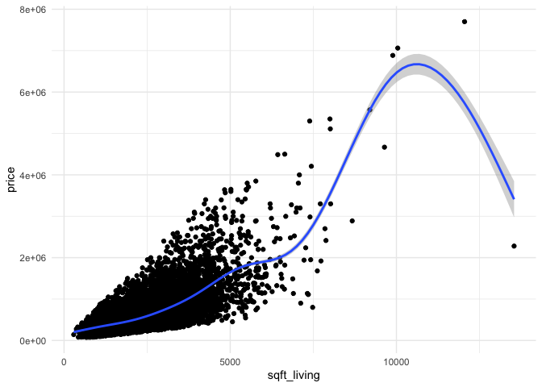

The model summary indicates that ‘sqft_living’ is a significant predictor of house price. However, the model explains only 55% of the variance, suggesting that incorporating additional covariates could improve its predictive power.

Then, by looking at the residuals plots, we can notice that:

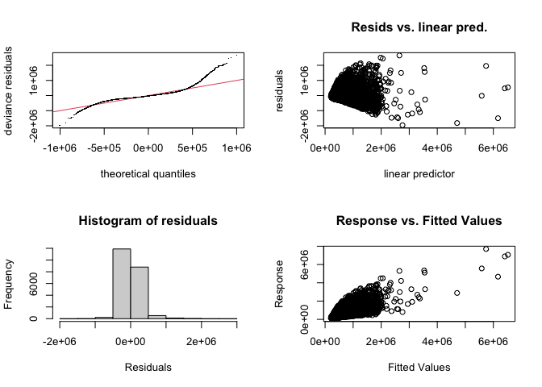

```
##
## Method: GCV   Optimizer: magic
## Smoothing parameter selection converged after 10 iterations.
## The RMS GCV score gradient at convergence was 34210.78 .
## The Hessian was positive definite.
## Model rank =  10 / 10
##
## Basis dimension (k) checking results. Low p-value (k-index<1) may
## indicate that k is too low, especially if edf is close to k'.
##
##                  k'  edf k-index p-value
## s(sqft_living) 9.00 8.99       1    0.35
```

- the `QQ Plot` indicates non-normality of the residuals;
- the `Resids vs Fitted Plot` suggests the presence of patterns in the residuals that were not adequately captured by the model;
- the `Response vs Fitted Plot` reveals heteroscedasticity, with the residuals exhibiting greater variability for larger fitted values.

### Further consideration on the datset and EDA:

To enhance the model’s performance, we will incorporate additional covariates and consider transformations for both the response variable and predictors. Therefore, the following variables will be log-transformed for subsequent analyses:

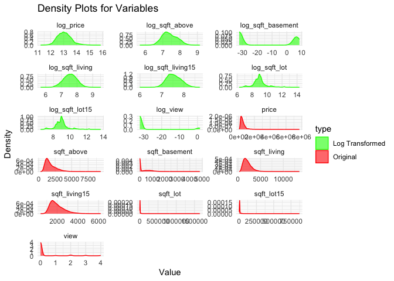

Now that we have transformed these variables, we can drop the non transformed versions:

```r
# Drop the non-transformed variables:
d <- d[, !grepl("^sqft_living$|^price$|^sqft_lot$|^view$|^sqft_above$|^sqft_basement$|^sqft_living15$|^sqft_lot15$", names(d))]
colnames(d)
```

```
##  [1] "id"                "date"              "bedrooms"
##  [4] "bathrooms"         "floors"            "waterfront"
##  [7] "condition"         "grade"             "yr_built"
## [10] "yr_renovated"      "zipcode"           "lat"
## [13] "long"              "log_price"         "log_sqft_living"
## [16] "log_sqft_lot"      "log_view"          "log_sqft_above"
## [19] "log_sqft_basement" "log_sqft_living15" "log_sqft_lot15"
```

To guide our model selection process, we will first investigate potential multicollinearity among the variables by examining a heatmap:

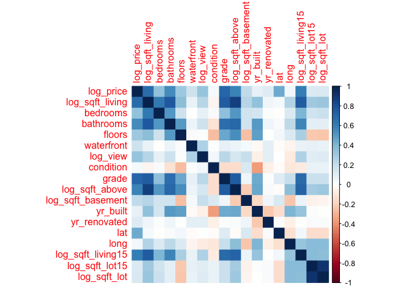

```
## 1. log_sqft_living15: 0.607
## 2. log_sqft_above: 0.586
## 3. bathrooms: 0.551
## 4. lat: 0.449
## 5. bedrooms: 0.344
## 6. log_view: 0.332
## 7. floors: 0.311
## 8. log_sqft_basement: 0.217
## 9. waterfront: 0.175
## 10. log_sqft_lot: 0.138
```

An examination of the heatmap reveals correlations among certain predictor variables. To address potential multicollinearity issues, we will re-examine the heatmap without the target variable. Predictors exhibiting high correlations will not be simultaneously included in the models.

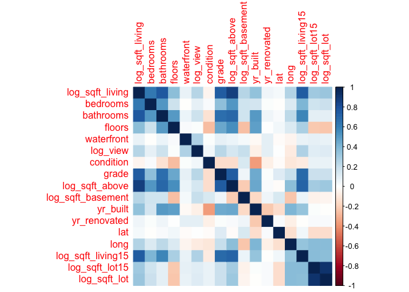

```
## Highly correlated variable pairs:
```

```
## - log_sqft_living is correlated with bathrooms with a value of: 0.761
## - log_sqft_living is correlated with grade with a value of: 0.744
## - log_sqft_living is correlated with log_sqft_above with a value of: 0.865
## - grade is correlated with log_sqft_above with a value of: 0.743
## - log_sqft_living is correlated with log_sqft_living15 with a value of: 0.746
## - log_sqft_above is correlated with log_sqft_living15 with a value of: 0.713
## - log_sqft_lot15 is correlated with log_sqft_lot with a value of: 0.919
```

Then, another important factor to consider is the location of the house:

[interactive chart not shown]

From the maps above, we can see that there are some city areas where the prices are significantly higher. These price variations emphasize the significant influence of location on housing values. Consequently, incorporating spatial variables into the model may be essential for a more accurate representation of the housing market.

### Fitting better models:

#### Splitting the dataset in train and test

Before fitting the model and to be able to asses the capacities of the models in predicting new data, we need to split the dataset in train and test:

```r
# dividing the data into training and test sets:
set.seed(42)
train_indices <- sample(1:nrow(d), 0.8 * nrow(d))
train_data <- d[train_indices,]
test_data <- d[-train_indices,]
```

#### Models fitting

We can start by fitting a model with the most correlated variables with the target variable, while excluding highly correlated predictor pairs:

```r
model_hc <- gam(log_price ~ s(log_sqft_living15) + s(bedrooms) + s(log_sqft_basement) + factor(waterfront) + s(log_sqft_lot), data = train_data)
# not considering s(floors) and s(log_view) because they have fewer unique covariate combinations than specified maximum degrees of freedom
```

Another approach would be to incorporate information about the house location, in addition to log_sqft_living.

- with the coordinates `te(lat, long)`:

```r
model_coordinates <- gam(log_price ~ s(log_sqft_living) + te(lat, long), data = train_data)
```

- with zipcode as a factor:

```r
model_zipcode <- gam(log_price ~ s(log_sqft_living) + factor(zipcode), data = train_data)
```

We may even combine these 2 strategies with a balanced model:

```r
model_mixed_strategies <- gam(log_price ~ s(log_sqft_living) + factor(zipcode) + s(bedrooms) + factor(waterfront), data = train_data)
```

#### Models evaluation

Now that we’ve fit these models, we can evaluate them based on their capacity to explain the target variable variance and their predictive efficacy on test_data:

##### Capacity to explain the target variable variance:

- Summaries:

```
## ----------- Model with highly correlated variables:
```

```
##
## Family: gaussian
## Link function: identity
##
## Formula:
## log_price ~ s(log_sqft_living15) + s(bedrooms) + s(log_sqft_basement) +
##     factor(waterfront) + s(log_sqft_lot)
##
## Parametric coefficients:
##                      Estimate Std. Error t value Pr(>|t|)
## (Intercept)         13.046462   0.002881 4528.34   <2e-16 ***
## factor(waterfront)1  0.690968   0.033526   20.61   <2e-16 ***
## ---
## Signif. codes:  0 '***' 0.001 '**' 0.01 '*' 0.05 '.' 0.1 ' ' 1
##
## Approximate significance of smooth terms:
##                        edf Ref.df      F p-value
## s(log_sqft_living15) 6.916  7.925 974.79  <2e-16 ***
## s(bedrooms)          6.878  7.604  40.82  <2e-16 ***
## s(log_sqft_basement) 6.173  7.221 132.61  <2e-16 ***
## s(log_sqft_lot)      8.705  8.974 136.71  <2e-16 ***
## ---
## Signif. codes:  0 '***' 0.001 '**' 0.01 '*' 0.05 '.' 0.1 ' ' 1
##
## R-sq.(adj) =  0.482   Deviance explained = 48.3%
## GCV = 0.14264  Scale est. = 0.14238   n = 17290
```

```
## ----------- Model with coordinates:
```

```
##
## Family: gaussian
## Link function: identity
##
## Formula:
## log_price ~ s(log_sqft_living) + te(lat, long)
##
## Parametric coefficients:
##              Estimate Std. Error t value Pr(>|t|)
## (Intercept) 13.051737   0.001779    7335   <2e-16 ***
## ---
## Signif. codes:  0 '***' 0.001 '**' 0.01 '*' 0.05 '.' 0.1 ' ' 1
##
## Approximate significance of smooth terms:
##                       edf Ref.df    F p-value
## s(log_sqft_living)  5.611  6.738 4809  <2e-16 ***
## te(lat,long)       23.830 23.991 1139  <2e-16 ***
## ---
## Signif. codes:  0 '***' 0.001 '**' 0.01 '*' 0.05 '.' 0.1 ' ' 1
##
## R-sq.(adj) =  0.801   Deviance explained = 80.1%
## GCV = 0.054841  Scale est. = 0.054744  n = 17290
```

```
## ----------- Model with zipcode as a factor:
```

```
##
## Family: gaussian
## Link function: identity
##
## Formula:
## log_price ~ s(log_sqft_living) + factor(zipcode)
##
## Parametric coefficients:
##                       Estimate Std. Error t value Pr(>|t|)
## (Intercept)          12.552395   0.013192 951.500  < 2e-16 ***
## factor(zipcode)98002 -0.050498   0.021762  -2.320  0.02033 *
## factor(zipcode)98003  0.035949   0.019801   1.816  0.06946 .
## factor(zipcode)98004  1.169849   0.019204  60.917  < 2e-16 ***
## factor(zipcode)98005  0.791836   0.022413  35.330  < 2e-16 ***
## factor(zipcode)98006  0.743882   0.017389  42.780  < 2e-16 ***
## factor(zipcode)98007  0.696459   0.024477  28.453  < 2e-16 ***
## factor(zipcode)98008  0.710232   0.019129  37.128  < 2e-16 ***
## factor(zipcode)98010  0.251100   0.028016   8.963  < 2e-16 ***
## factor(zipcode)98011  0.452665   0.022375  20.231  < 2e-16 ***
## factor(zipcode)98014  0.337935   0.025319  13.347  < 2e-16 ***
## factor(zipcode)98019  0.316938   0.022316  14.203  < 2e-16 ***
## factor(zipcode)98022  0.142694   0.020731   6.883 6.06e-12 ***
## factor(zipcode)98023 -0.007409   0.017191  -0.431  0.66649
## factor(zipcode)98024  0.502027   0.030337  16.548  < 2e-16 ***
## factor(zipcode)98027  0.541445   0.017812  30.398  < 2e-16 ***
## factor(zipcode)98028  0.431375   0.019277  22.378  < 2e-16 ***
## factor(zipcode)98029  0.651481   0.018870  34.525  < 2e-16 ***
## factor(zipcode)98030  0.044165   0.020122   2.195  0.02819 *
## factor(zipcode)98031  0.093330   0.019777   4.719 2.39e-06 ***
## factor(zipcode)98032 -0.034965   0.025987  -1.345  0.17849
## factor(zipcode)98033  0.821939   0.017654  46.557  < 2e-16 ***
## factor(zipcode)98034  0.551310   0.016672  33.069  < 2e-16 ***
## factor(zipcode)98038  0.177503   0.016577  10.708  < 2e-16 ***
## factor(zipcode)98039  1.389999   0.036485  38.097  < 2e-16 ***
## factor(zipcode)98040  1.015596   0.020013  50.746  < 2e-16 ***
## factor(zipcode)98042  0.074031   0.016845   4.395 1.12e-05 ***
## factor(zipcode)98045  0.376811   0.021194  17.779  < 2e-16 ***
## factor(zipcode)98052  0.672942   0.016742  40.195  < 2e-16 ***
## factor(zipcode)98053  0.624095   0.017885  34.895  < 2e-16 ***
## factor(zipcode)98055  0.142270   0.019729   7.211 5.78e-13 ***
```

[output cut: 35 more lines]

```
## factor(zipcode)98178  0.136064   0.019969   6.814 9.82e-12 ***
## factor(zipcode)98188  0.065346   0.025217   2.591  0.00957 **
## factor(zipcode)98198  0.100645   0.019683   5.113 3.20e-07 ***
## factor(zipcode)98199  0.901799   0.018881  47.763  < 2e-16 ***
## ---
## Signif. codes:  0 '***' 0.001 '**' 0.01 '*' 0.05 '.' 0.1 ' ' 1
##
## Approximate significance of smooth terms:
##                      edf Ref.df    F p-value
## s(log_sqft_living) 5.456  6.582 4528  <2e-16 ***
## ---
## Signif. codes:  0 '***' 0.001 '**' 0.01 '*' 0.05 '.' 0.1 ' ' 1
##
## R-sq.(adj) =  0.827   Deviance explained = 82.8%
## GCV = 0.0478  Scale est. = 0.047592  n = 17290
```

```
## ----------- Model with mixed strategies:
```

```
##
## Family: gaussian
## Link function: identity
##
## Formula:
## log_price ~ s(log_sqft_living) + factor(zipcode) + s(bedrooms) +
##     factor(waterfront)
##
## Parametric coefficients:
##                      Estimate Std. Error t value Pr(>|t|)
## (Intercept)          12.55159    0.01256 999.382  < 2e-16 ***
## factor(zipcode)98002 -0.04644    0.02071  -2.242 0.024967 *
## factor(zipcode)98003  0.03599    0.01885   1.910 0.056184 .
## factor(zipcode)98004  1.17895    0.01828  64.496  < 2e-16 ***
## factor(zipcode)98005  0.79993    0.02133  37.501  < 2e-16 ***
## factor(zipcode)98006  0.74455    0.01655  44.988  < 2e-16 ***
## factor(zipcode)98007  0.70920    0.02330  30.433  < 2e-16 ***
## factor(zipcode)98008  0.69630    0.01823  38.205  < 2e-16 ***
## factor(zipcode)98010  0.24741    0.02666   9.279  < 2e-16 ***
## factor(zipcode)98011  0.45292    0.02130  21.267  < 2e-16 ***
## factor(zipcode)98014  0.32841    0.02412  13.617  < 2e-16 ***
## factor(zipcode)98019  0.31325    0.02124  14.749  < 2e-16 ***
## factor(zipcode)98022  0.13769    0.01973   6.977 3.12e-12 ***
## factor(zipcode)98023 -0.01604    0.01636  -0.980 0.326984
## factor(zipcode)98024  0.50210    0.02888  17.387  < 2e-16 ***
## factor(zipcode)98027  0.53790    0.01696  31.716  < 2e-16 ***
## factor(zipcode)98028  0.42814    0.01835  23.337  < 2e-16 ***
## factor(zipcode)98029  0.64537    0.01797  35.923  < 2e-16 ***
## factor(zipcode)98030  0.04555    0.01915   2.379 0.017388 *
## factor(zipcode)98031  0.09390    0.01882   4.989 6.12e-07 ***
## factor(zipcode)98032 -0.02880    0.02474  -1.164 0.244319
## factor(zipcode)98033  0.81659    0.01680  48.599  < 2e-16 ***
## factor(zipcode)98034  0.54683    0.01587  34.460  < 2e-16 ***
## factor(zipcode)98038  0.17340    0.01578  10.990  < 2e-16 ***
## factor(zipcode)98039  1.38604    0.03472  39.924  < 2e-16 ***
## factor(zipcode)98040  0.99710    0.01906  52.322  < 2e-16 ***
## factor(zipcode)98042  0.07299    0.01603   4.552 5.34e-06 ***
## factor(zipcode)98045  0.37057    0.02018  18.364  < 2e-16 ***
## factor(zipcode)98052  0.66814    0.01593  41.930  < 2e-16 ***
## factor(zipcode)98053  0.61486    0.01708  36.001  < 2e-16 ***
```

[output cut: 38 more lines]

```
## factor(zipcode)98198  0.07205    0.01875   3.843 0.000122 ***
## factor(zipcode)98199  0.89367    0.01799  49.686  < 2e-16 ***
## factor(waterfront)1   0.69711    0.01869  37.305  < 2e-16 ***
## ---
## Signif. codes:  0 '***' 0.001 '**' 0.01 '*' 0.05 '.' 0.1 ' ' 1
##
## Approximate significance of smooth terms:
##                      edf Ref.df       F p-value
## s(log_sqft_living) 5.037  6.152 3610.27  <2e-16 ***
## s(bedrooms)        4.909  5.772   56.06  <2e-16 ***
## ---
## Signif. codes:  0 '***' 0.001 '**' 0.01 '*' 0.05 '.' 0.1 ' ' 1
##
## R-sq.(adj) =  0.843   Deviance explained = 84.4%
## GCV = 0.043298  Scale est. = 0.043095  n = 17290
```

From these summaries we can see how the models that take into account the house location perform significantly better.

- Residual plots:
  - model_hc:

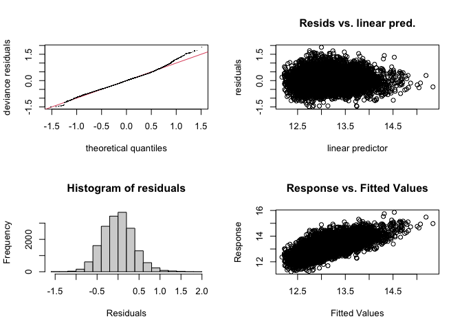

```
##
## Method: GCV   Optimizer: magic
## Smoothing parameter selection converged after 20 iterations.
## The RMS GCV score gradient at convergence was 2.825354e-07 .
## The Hessian was positive definite.
## Model rank =  38 / 38
##
## Basis dimension (k) checking results. Low p-value (k-index<1) may
## indicate that k is too low, especially if edf is close to k'.
##
##                        k'  edf k-index p-value
## s(log_sqft_living15) 9.00 6.92    0.99   0.175
## s(bedrooms)          9.00 6.88    1.01   0.805
## s(log_sqft_basement) 9.00 6.17    1.00   0.620
## s(log_sqft_lot)      9.00 8.71    0.97   0.025 *
## ---
## Signif. codes:  0 '***' 0.001 '**' 0.01 '*' 0.05 '.' 0.1 ' ' 1
```

- model_coordinates:

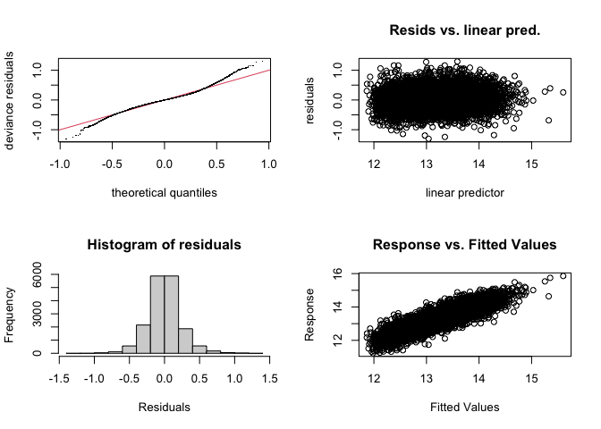

```
##
## Method: GCV   Optimizer: magic
## Smoothing parameter selection converged after 9 iterations.
## The RMS GCV score gradient at convergence was 9.476791e-08 .
## The Hessian was positive definite.
## Model rank =  34 / 34
##
## Basis dimension (k) checking results. Low p-value (k-index<1) may
## indicate that k is too low, especially if edf is close to k'.
##
##                       k'   edf k-index p-value
## s(log_sqft_living)  9.00  5.61    0.99    0.25
## te(lat,long)       24.00 23.83    0.68  <2e-16 ***
## ---
## Signif. codes:  0 '***' 0.001 '**' 0.01 '*' 0.05 '.' 0.1 ' ' 1
```

- model_zipcode:

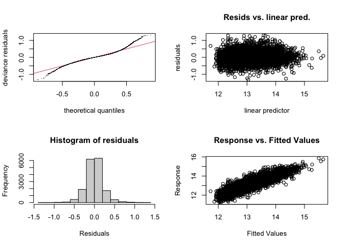

```
##
## Method: GCV   Optimizer: magic
## Smoothing parameter selection converged after 6 iterations.
## The RMS GCV score gradient at convergence was 3.224878e-07 .
## The Hessian was positive definite.
## Model rank =  79 / 79
##
## Basis dimension (k) checking results. Low p-value (k-index<1) may
## indicate that k is too low, especially if edf is close to k'.
##
##                      k'  edf k-index p-value
## s(log_sqft_living) 9.00 5.46    1.02    0.88
```

- model_mixed_strategies:

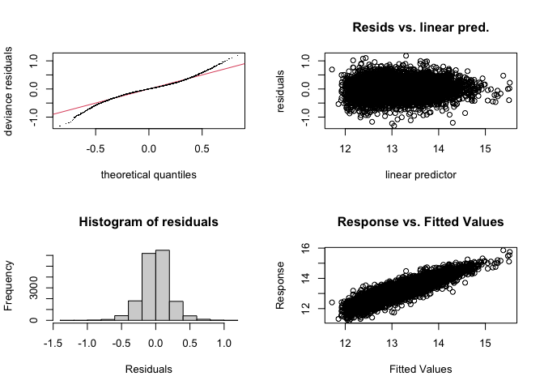

```
##
## Method: GCV   Optimizer: magic
## Smoothing parameter selection converged after 6 iterations.
## The RMS GCV score gradient at convergence was 8.126426e-08 .
## The Hessian was positive definite.
## Model rank =  89 / 89
##
## Basis dimension (k) checking results. Low p-value (k-index<1) may
## indicate that k is too low, especially if edf is close to k'.
##
##                      k'  edf k-index p-value
## s(log_sqft_living) 9.00 5.04    0.99    0.28
## s(bedrooms)        9.00 4.91    1.01    0.71
```

##### Predictive efficacy:

To understand how well the models perform, we can calculate the Root Mean Squared Error (RMSE) and Mean Absolute Error (MAE) on the test data:

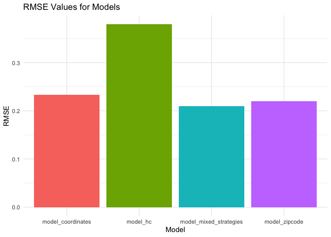

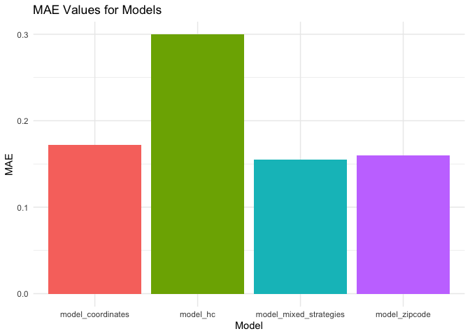

We can also plot the predicted vs actual values and the residuals for each model:

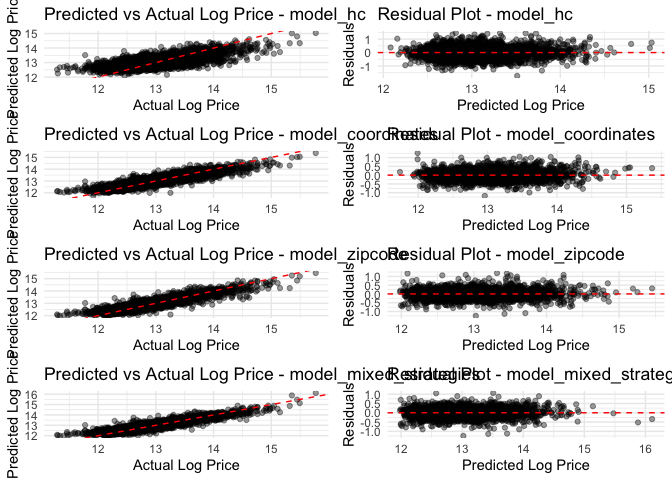

Overall, the best choice would be `model_zipcode`, because:

- it is a good compromise between a simple and understandable model and a low GCV (Generalized Cross-Validation) score;
- it has low RMSE and MAE values on the test data;
- it has a good predictive efficacy, as shown by the predicted vs actual values and residuals plots.

## Devise a model to assess whether there is any seasonality in the price.

To investigate potential seasonality in prices, we can include variables representing the month and quarter of the year in which the sales occurred.

The first step is to extract the month or quarter to analyze seasonal trends:

```
##         date month quarter
## 1 2014-10-13    10       4
## 2 2014-12-09    12       4
## 3 2015-02-25     2       1
## 4 2014-12-09    12       4
## 5 2015-02-18     2       1
## 6 2014-05-12     5       2
```

Then, we can check any seasonal patterns in the data by plotting the boxplots of the price distribution by month and quarter:

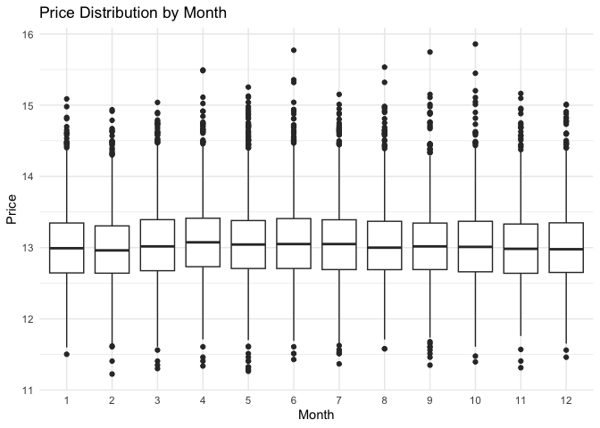

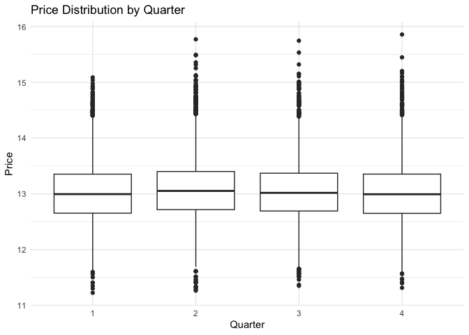

We can also print the anova values for the monthly and quarterly price differences:

```r
# ANOVA for Monthly Price Differences
anova_month_result <- aov(log_price ~ factor(month), data = d)
summary(anova_month_result)
```

```
##                  Df Sum Sq Mean Sq F value   Pr(>F)
## factor(month)    11     18  1.6007   5.784 2.02e-09 ***
## Residuals     21601   5977  0.2767
## ---
## Signif. codes:  0 '***' 0.001 '**' 0.01 '*' 0.05 '.' 0.1 ' ' 1
```

```r
# ANOVA for Quarterly Price Differences
anova_quarter_result <- aov(log_price ~ factor(quarter), data = d)
summary(anova_quarter_result)
```

```
##                    Df Sum Sq Mean Sq F value   Pr(>F)
## factor(quarter)     3     12   4.100   14.81 1.25e-09 ***
## Residuals       21609   5983   0.277
## ---
## Signif. codes:  0 '***' 0.001 '**' 0.01 '*' 0.05 '.' 0.1 ' ' 1
```

Both summaries indicate that both `month` and `quarter` have a significant effect on the response variable. This means that the average value of the response variable differs significantly across the different months and quarters.

However, 4 quarters are too few to fit a spline model, so we can only fit the model for the months.

Hence, we can consider the average log_price for each month:

```r
# Dataframe with month and the average log_price for each month
df_month <- d %>%
  group_by(month) %>%
  summarise(avg_log_price = mean(log_price, na.rm = TRUE))
```

And fit a spline model:

```r
model_month <- gam(avg_log_price ~ s(month), data = df_month)
```

```
##
## Family: gaussian
## Link function: identity
##
## Formula:
## avg_log_price ~ s(month)
##
## Parametric coefficients:
##              Estimate Std. Error t value Pr(>|t|)
## (Intercept) 13.041569   0.005043    2586   <2e-16 ***
## ---
## Signif. codes:  0 '***' 0.001 '**' 0.01 '*' 0.05 '.' 0.1 ' ' 1
##
## Approximate significance of smooth terms:
##            edf Ref.df    F p-value
## s(month) 3.259  4.042 5.83  0.0168 *
## ---
## Signif. codes:  0 '***' 0.001 '**' 0.01 '*' 0.05 '.' 0.1 ' ' 1
##
## R-sq.(adj) =   0.68   Deviance explained = 77.5%
## GCV = 0.0004731  Scale est. = 0.0003052  n = 12
```

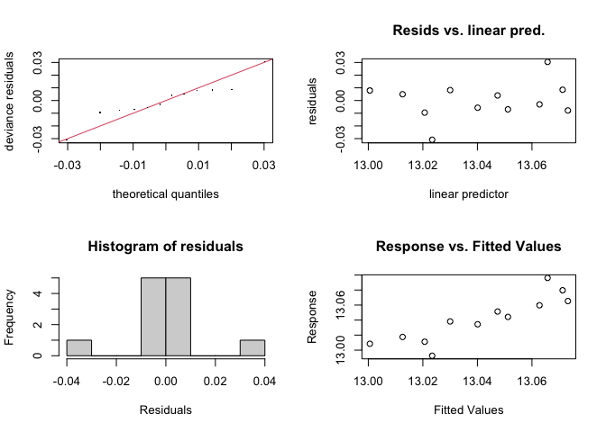

```
##
## Method: GCV   Optimizer: magic
## Smoothing parameter selection converged after 4 iterations.
## The RMS GCV score gradient at convergence was 2.556177e-09 .
## The Hessian was positive definite.
## Model rank =  10 / 10
##
## Basis dimension (k) checking results. Low p-value (k-index<1) may
## indicate that k is too low, especially if edf is close to k'.
##
##            k'  edf k-index p-value
## s(month) 9.00 3.26    1.39    0.81
```

For the limited data that we have, we could say that the model fits well enough the data. Furthermore, it suggests significant differences in the average price of the houses across the months.